# Benchmarking Signac and SingleR with synovial flow cytometry data

Mathew Chamberlain

2021-02-12

# Contents

This vignette shows how to use Signac to annotate flow-sorted synovial cells by integrating Signac with Seurat. We start with raw counts.

## 0.1 Load data

Read the CEL-seq2 data.

```r
ReadCelseq <- function (counts.file, meta.file)
{
  E = suppressWarnings(readr::read_tsv(counts.file));
  gns <- E$gene;
  E = E[,-1]
  E = Matrix::Matrix(as.matrix(E), sparse = TRUE)
  rownames(E) <- gns
  E
}

counts.file = "./celseq_matrix_ru10_molecules.tsv.gz"
meta.file = "./celseq_meta.immport.723957.tsv"

E = ReadCelseq(counts.file = counts.file, meta.file = meta.file)
M = suppressWarnings(readr::read_tsv(meta.file))

# filter data based on depth and number of genes detected
kmu = Matrix::colSums(E != 0)
kmu2 = Matrix::colSums(E)
E = E[,kmu > 200 & kmu2 > 500]

# filter by mitochondrial percentage
logik = grepl("^MT-", rownames(E))
MitoFrac = Matrix::colSums(E[logik,]) / Matrix::colSums(E) * 100
E = E[,MitoFrac < 20]
```

## 0.2 SingleR

```r
library(SingleR)
data("hpca")
Q = SingleR(sc_data = E, ref_data = hpca$data, types = hpca$main_types, fine.tune = F, numCores = 16)
save(file = "SingleR_Results.rda", Q)
True_labels = M$type[match(colnames(E), M$cell_name)]
```

## 0.3 Seurat

Start with the standard pre-processing steps for a Seurat object.

```r
library(Seurat)
```

Create a Seurat object, and then perform SCTransform normalization. Note:

- You can use the legacy functions here (i.e., NormalizeData, ScaleData, etc.), use SCTransform or any other normalization method (including no normalization). We did not notice a significant difference in cell type annotations with different normalization methods.
- We think that it is best practice to use SCTransform, but it is not a necessary step. Signac will work fine without it.

```r
# load data
synovium <- CreateSeuratObject(counts = E, project = "FACs")

# run sctransform
synovium <- SCTransform(synovium, verbose = F)
```

Perform dimensionality reduction by PCA and UMAP embedding. Note:

- Signac actually needs these functions since it uses the nearest neighbor graph generated by Seurat.

```r
# These are now standard steps in the Seurat workflow for visualization and clustering
synovium <- RunPCA(synovium, verbose = FALSE)
synovium <- RunUMAP(synovium, dims = 1:30, verbose = FALSE)
synovium <- FindNeighbors(synovium, dims = 1:30, verbose = FALSE)
```

## 0.4 Signac

First, make sure that you have the Signac package installed.

```r
devtools::install_github("mathewchamberlain/Signac")
library(Signac)
```

Generate Signac labels for the Seurat object. Note:

- Optionally, you can do parallel computing by setting num.cores > 1 in the Signac function.
- Run time is ~10 minutes for ~10,000 cells on a single core.

```r
# Run Signac
data("training_HPCA")
labels <- Signac(synovium, R = training_HPCA)
celltypes = Generate_lbls(labels, E = synovium)
```

## 0.5 Visualizations

Visualize the cell type classifications from Signac

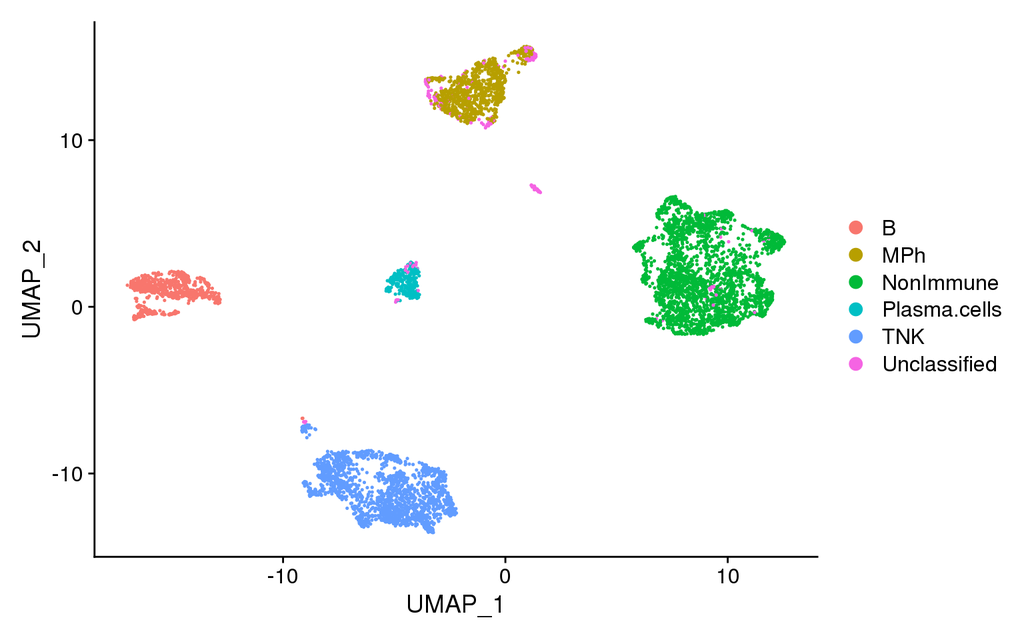

```r
lbls = factor(celltypes$CellTypes)
levels(lbls) <- sort(unique(lbls))
synovium <- Seurat::AddMetaData(synovium, metadata=lbls, col.name = "celltypes")
synovium <- Seurat::SetIdent(synovium, value='celltypes')
DimPlot(synovium)
```

Compare Signac with FACs labels

Note: * These data were flow-sorted for CD3, and therefore lack NK cells. Signac detected no NK cells.

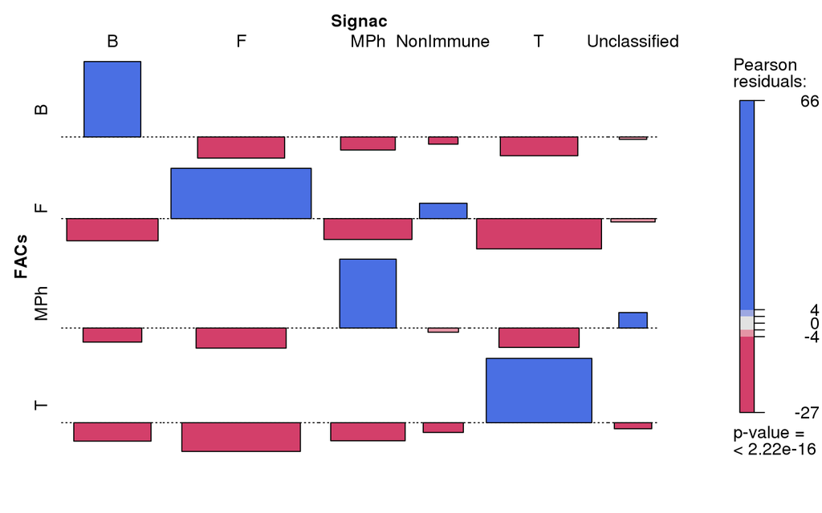

Note: * F = Fibroblasts; M = monocytes; T = T cells; B = B cells * Association plot indicates the deviations from a specified independence model in high-dimensional contingency table. See the “assoc” function in the vcd package.

Compute Signac accuracy

```r
logik = xx != "Unclassified"
Signac_Accuracy = round(sum(xx[logik] == True_labels[logik]) / sum(logik) * 100, 2)
Signac_Accuracy
```

```
## [1] 95.08
```

Compare SingleR with FACs labels

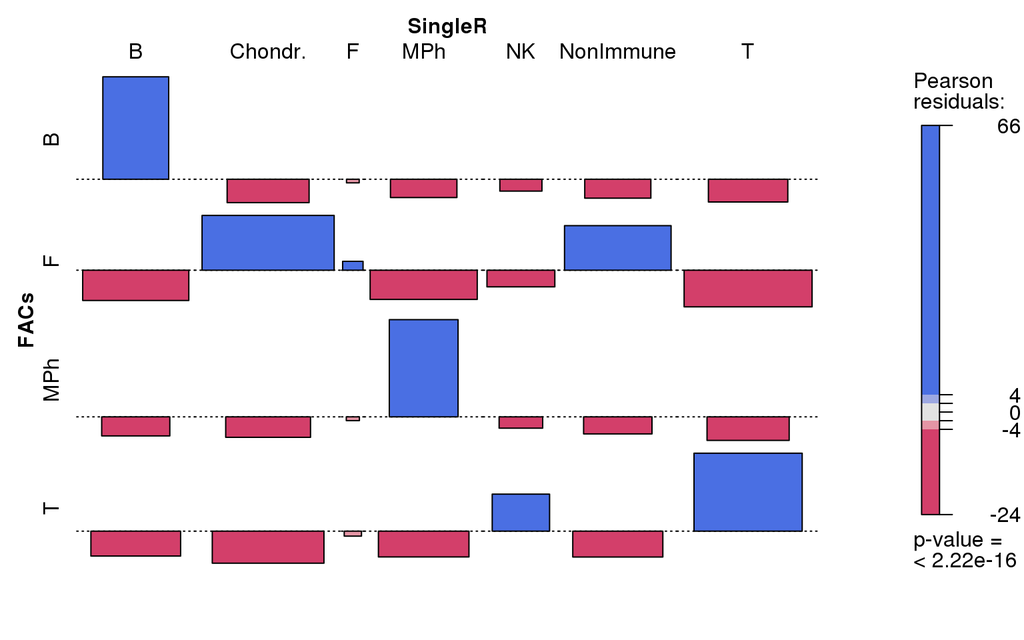

Note that SingleR inaccurately annotated the majority of fibroblast cells as Chondrocytes (Chondr.) and non immune cells, and also significantly identified NK cells (even though the data were flow-sorted for CD3, and thus empirically lacks NK cells).

Compute SingleR accuracy

```r
logik = xx != "Unclassified"
SingleR_Accuracy = round(sum(xx[logik] == True_labels[logik]) / sum(logik) * 100, 2)
SingleR_Accuracy
```

```
## [1] 53.51
```

Save results

```r
saveRDS(synovium, file = "synovium_signac.rds")
saveRDS(celltypes, file = "synovium_signac_celltypes.rds")
```

A work by [Mathew Chamberlain](https://github.com/m137/)

*mathew.chamberlain@sanofi.com*